# Lab 1

# Lendo dados

```r
all_series = read_csv(here("data/series_from_imdb.csv.zip"),
                      col_types = "ccdcdcdddddddddddd")
```

# 1 - Quais das séries de drama na netflix listadas abaixo são as mais bem avaliadas ?

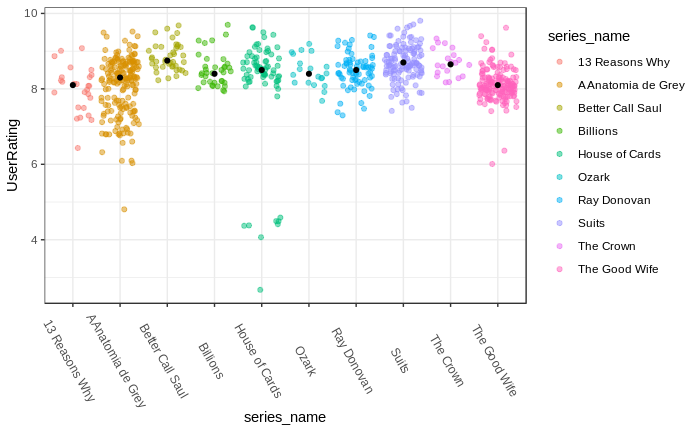

```r
drama_series <- c("13 Reasons Why", "Better Call Saul", "Billions", "A Anatomia de Grey", "House of Cards",  "Ozark", "Ray Donovan", "Suits", "The Crown", "The Good Wife")
sumario = all_series %>%
    filter(series_name %in% drama_series) %>%
    group_by(series_name) %>%
    summarise(median_series = median(UserRating))
all_series %>%
    filter(series_name %in% drama_series) %>%
    group_by(series_name) %>%
    ggplot(aes(x = series_name, y = UserRating, color = series_name)) +
    theme(axis.text.x = element_text(angle = -60)) +
    geom_jitter(alpha = .5) +
    geom_point(data = sumario,
            mapping = aes(x = series_name, y = median_series),
            color = "black",
            size = 1.5)
```

```r
#TODO: pintar o minino de outra cor
```

# 2 - Quais das séries de ficção-científica na netflix listadas abaixo tem a pior avaliação ?

Series: Black Mirror, Dark, The Expanse, Altered Carbon, Os 100, 3%, Travelers, Mars

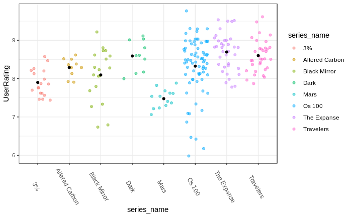

```r
fiction_series <- c("Black Mirror", "Dark", "The Expanse", "Altered Carbon", "Os 100", "3%", "Travelers", "Mars")
sumario = all_series %>%
    filter(series_name %in% fiction_series) %>%
    group_by(series_name) %>%
    summarise(median_series = mean(UserRating))
all_series %>%
    filter(series_name %in% fiction_series) %>%
    group_by(series_name) %>%
    ggplot(aes(x = series_name, y = UserRating, color = series_name)) +
    geom_jitter(alpha = .5) +
    theme(axis.text.x = element_text(angle = -60)) +
    geom_point(data = sumario,
            mapping = aes(x = series_name, y = median_series),
            color = "black",
            size = 1.5)
```

# 3 - Quais as durações médias das séries: Grey’s Anatomy, Black Mirror, Strangers Thing, Sex and The City, Avatar: A Lenda de Korra, Orange Is the New Black, House of Cards e The Good Wife ?

R: Das séries escolhidas podemos observar que A Anatomia de Grey tem a maior duração, seguida por The Good Wife. Sex and the City também apresenta uma duração grande. As demais series apresentam uma duração parecida, com exceção de Strager Things e Black Mirror que são series atuais e que ainda possuem pouco episódios.

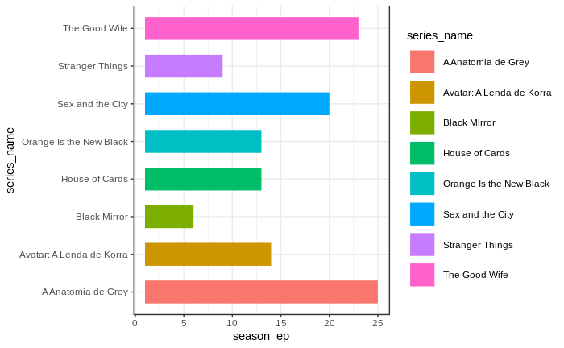

```r
my_series <- c("A Anatomia de Grey",  "Black Mirror", "Stranger Things", "Sex and the City", "Avatar: A Lenda de Korra", "Orange Is the New Black", "House of Cards", "The Good Wife")
all_series %>%
    filter(series_name %in% my_series) %>%
    group_by(series_name) %>%
    ggplot(aes(x = season_ep, y = series_name, color = series_name)) +
    geom_line(size = 10 )
```

# 4 - Quais as melhores e piores temporadas de Grey’s Anatomy ?

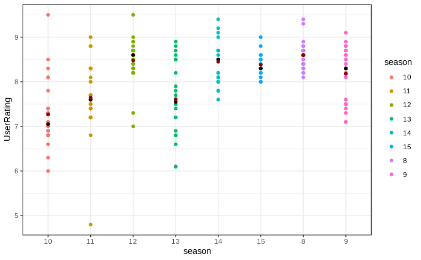

```r
sumario = all_series %>%
    filter(series_name == "A Anatomia de Grey") %>%
    group_by(season) %>%
    summarise(median_series = median(UserRating), media = mean(UserRating))
all_series %>%
    filter(series_name == "A Anatomia de Grey") %>%
    group_by(season) %>%
    ggplot(aes(x = season, y = UserRating, color = season)) +
    geom_point() +
    geom_point(data = sumario,
            mapping = aes(x = season, y = median_series),
            color = "black",
            size = 1.5) +
    geom_point(data = sumario,
            mapping = aes(x = season, y = media),
            color = "darkred",
            size = 1.5)
```

```r
#TODO: ajeitar a ordem
```

# 5 - Qual episódio de Strangers Things tem mais notas 0 e 10 ?

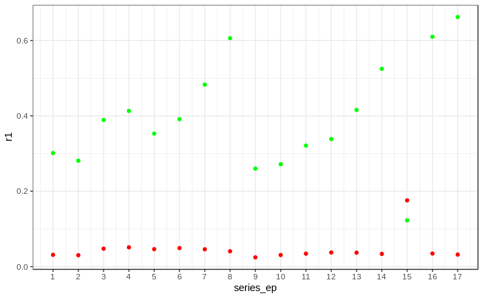

```r
all_series %>%
    filter(series_name == "Stranger Things") %>%
    group_by(season) %>%
    ggplot() +
    geom_point(aes(x = series_ep, y = r1), color = "red") +
    geom_point(aes(x = series_ep, y = r10), color = 'green') +
    scale_x_continuous(breaks = 1:18)
```

```r
# verde  = r10, vermelho = r1
#TODO: Colocar legenda acima no grafico
```

# 6 - Orange is the new black melhorou ou piorou com o tempo ?

R: O primeiro gráfico mostra a nota de cada episódio separado por temporada. É visível que todo episódio de final de temporada tem uma nota maior que todos os episódios da temporada, ou seja, todo episódio final de temporada é amado pelo público. É difícil responder qual a melhor temporada olhando apenas para o primeiro gráfico porém a 4º temporada parece apresentar os melhores episódios, inclusive nesta está o episódio mais bem votado de toda a série. Ao plotar as notas médias de cada temporada no segundo gráfico, as hipotesés são confirmadas a 4º apresenta a melhor nota. Apesar da ultima tempora ser a pior, a serie não apresenta um decaimento gradual de acordo com as tempordas.

```r
sumario = all_series %>%
    filter(series_name == "Orange Is the New Black") %>%
    group_by(season) %>%
    summarise(median_series = median(UserRating)) %>%
    glimpse()
```

```
Observations: 6
Variables: 2
$ season        <chr> "1", "2", "3", "4", "5", "6"
$ median_series <dbl> 8.1, 8.4, 8.0, 8.5, 8.2, 8.0
```

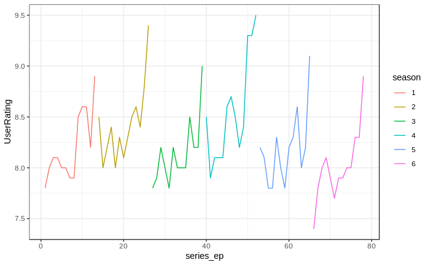

```r
all_series %>%
    filter(series_name == "Orange Is the New Black") %>%
    group_by(season) %>%
    ggplot(aes(x = series_ep, y = UserRating, color =  season)) +
    geom_line()
```

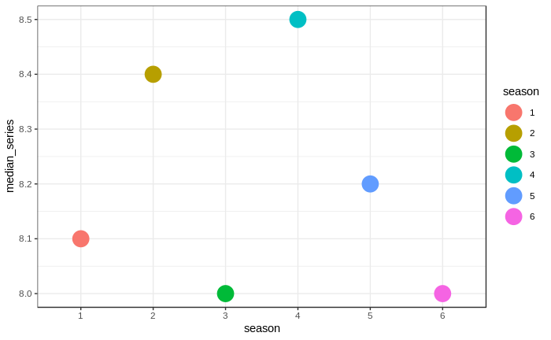

```r
sumario %>%
    ggplot(aes(x = season, y = median_series, color = season)) +
    geom_point(size = 7)
```